#### lab 2 : Elyasaf Cohen and Noa Grinderfer

204587612, 311524680

## 1 Simulation Study

### Kmeans and pca+Kmeans accuracy

A function that genrates 3 vector as asked and outputs a simulated dataset of dimension 100×p, givven the number of columns and the sd.

```r
sim <- function(p, sd){
  #Generate the first 10 coordinates of each µj vector j = 1, .., 3.
  m1 <- rnorm(10, mean=0, sd=1)
  m2 <- rnorm(10, mean=0, sd=1)
  m3 <- rnorm(10, mean=0, sd=1)
      X = matrix(rnorm(100*p,mean=0,sd=sd), 100, p)
      for (col in 1:10){
        #group A
        for (a in 1:20){
        X[a,col] = rnorm(1, mean=m1[col], sd=sd)}
        #group B
      for (b in 21:50){
        X[b,col] = rnorm(1, mean=m2[col], sd=sd)}
        #group C
      for (c in 51:100){
        X[c,col] = rnorm(1, mean=m3[col], sd=sd)}}
      return(X)
}
```

Compute the average accuracy and the std-err for each (p, σ2, algorithm).

summarising the full df to all combinations and Display these in a table:

```r
start_range <- seq(1,600,50)
end_range <- seq(50,600,50)
df <- data.frame()
for (i in 1:12){
 df <-rbind(df, mean_and_std(full_df[start_range[i]:end_range[i],]))
}
colnames(df) <- c("kmeans","pca_kmeans","std_kmeans","std_pca_kmeans","runtime","sd","p")

df
```

```
##    kmeans pca_kmeans std_kmeans std_pca_kmeans     runtime  sd  p
## 1  0.5200     0.5096 0.10165970     0.08717611 0.007299047 3.0 10
## 2  0.7896     0.7694 0.15399337     0.15642459 0.007674456 1.5 10
## 3  0.9432     0.9194 0.09009926     0.11547276 0.005939803 1.0 10
## 4  0.9378     0.9696 0.12924553     0.09514586 0.005822358 0.2 10
## 5  0.4916     0.4760 0.08881809     0.06382374 0.006658344 3.0 20
## 6  0.7598     0.6888 0.16361952     0.16382270 0.006385956 1.5 20
## 7  0.9062     0.8248 0.14236745     0.16831069 0.006689925 1.0 20
## 8  0.9402     0.9440 0.12721475     0.13002355 0.005960240 0.2 20
## 9  0.4714     0.4604 0.06318163     0.05244706 0.008980155 3.0 50
## 10 0.6624     0.5634 0.17413483     0.11827364 0.008977799 1.5 50
## 11 0.8584     0.7248 0.14018530     0.16082035 0.009049983 1.0 50
## 12 0.9432     0.9714 0.12393020     0.09125027 0.009079900 0.2 50
```

creating 3 df for each p.

```r
df10 <- df[1:4,1:6]
df20 <- df[5:8,1:6]
df50 <- df[9:12,1:6]

df10
```

```
##   kmeans pca_kmeans std_kmeans std_pca_kmeans     runtime  sd
## 1 0.5200     0.5096 0.10165970     0.08717611 0.007299047 3.0
## 2 0.7896     0.7694 0.15399337     0.15642459 0.007674456 1.5
## 3 0.9432     0.9194 0.09009926     0.11547276 0.005939803 1.0
## 4 0.9378     0.9696 0.12924553     0.09514586 0.005822358 0.2
```

```r
df20
```

```
##   kmeans pca_kmeans std_kmeans std_pca_kmeans     runtime  sd
## 5 0.4916     0.4760 0.08881809     0.06382374 0.006658344 3.0
## 6 0.7598     0.6888 0.16361952     0.16382270 0.006385956 1.5
## 7 0.9062     0.8248 0.14236745     0.16831069 0.006689925 1.0
## 8 0.9402     0.9440 0.12721475     0.13002355 0.005960240 0.2
```

```r
df50
```

```
##    kmeans pca_kmeans std_kmeans std_pca_kmeans     runtime  sd
## 9  0.4714     0.4604 0.06318163     0.05244706 0.008980155 3.0
## 10 0.6624     0.5634 0.17413483     0.11827364 0.008977799 1.5
## 11 0.8584     0.7248 0.14018530     0.16082035 0.009049983 1.0
## 12 0.9432     0.9714 0.12393020     0.09125027 0.009079900 0.2
```

Plotting the whole data in 4 plots, showing the mean and std of the two algotrithms for each p, and one plot which with all the p combined.

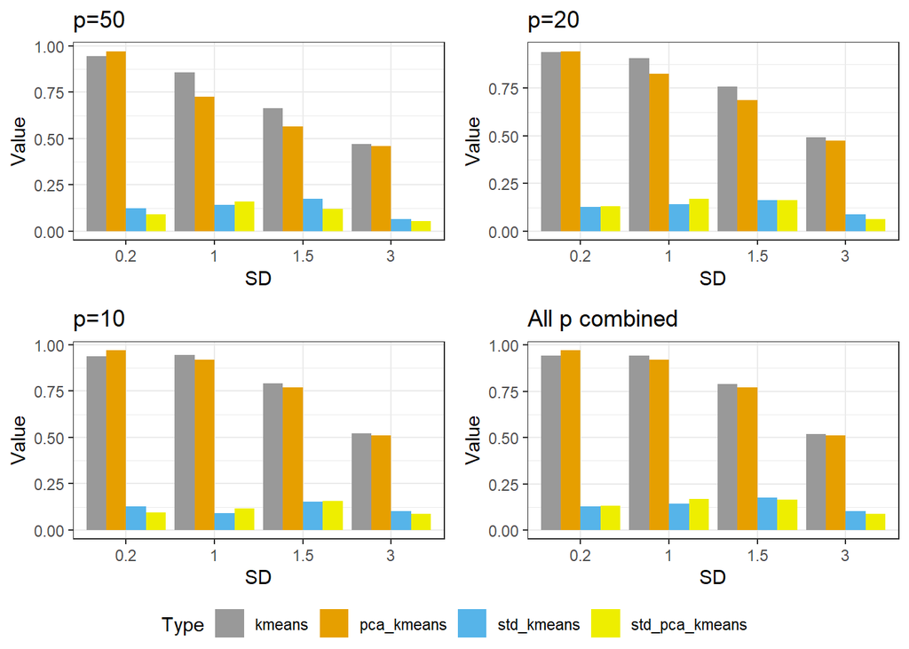

```r
#plot p =10
a <- df10 %>%
      gather("Type", "Value",-sd,-runtime) %>%
      ggplot(aes(factor(sd), Value, fill = Type)) +
      geom_bar(position = "dodge", stat = "identity") +
      scale_fill_manual(values=c("#999999", "#E69F00", "#56B4E9","yellow2"))+
      xlab("SD")+labs(title = "p=10")+
      theme(plot.title = element_text(hjust = 0.5))+
      theme_bw()
#plot p =20
b <- df20 %>%
  gather("Type", "Value",-sd,-runtime) %>%
  ggplot(aes(factor(sd), Value, fill = Type)) +
  geom_bar(position = "dodge", stat = "identity") +
  scale_fill_manual(values=c("#999999", "#E69F00", "#56B4E9","yellow2"))+
  xlab("SD")+labs(title = "p=20")+
  theme(plot.title = element_text(hjust = 0.5))+
  theme_bw()
#plot p= 50
c <- df50 %>%
  gather("Type", "Value",-sd,-runtime) %>%
  ggplot(aes(factor(sd), Value, fill = Type)) +
  geom_bar(position = "dodge", stat = "identity") +
  scale_fill_manual(values=c("#999999", "#E69F00", "#56B4E9","yellow2"))+
  xlab("SD")+labs(title = "p=50")+
  theme(plot.title = element_text(hjust = 0.5))+
  theme_bw()
#plot combined all p
d <- df %>%
  gather("Type", "Value",-sd,-p,-runtime) %>%
  ggplot(aes(factor(sd), Value, fill = Type)) +
  geom_bar(position = "dodge", stat = "identity") +
  scale_fill_manual(values=c("#999999", "#E69F00", "#56B4E9","yellow2"))+
  xlab("SD")+labs(title = "All p combined")+
  theme(plot.title = element_text(hjust = 0.5))+
  theme_bw()

library("ggpubr")
ggarrange(c,b,a,d, ncol=2, nrow=2, common.legend = TRUE, legend="bottom")
```

In order to show all the data in a figure I decided to show all the data (mean and std of the two combination) in 4 figures representing different number of p. We can see in the figure the all the plot have the same trand, which shows that as long as the variance we chose is smaller, as more as the acourrcy is higher and vice verca. This trand is clear and easy to explain, becasue a big varience leads to a lake of accouracy. We see that becouse of the numbers of p dont have huge gaps the results of accuracy in all of them is quite similar and what that makes the difrances is the variace.

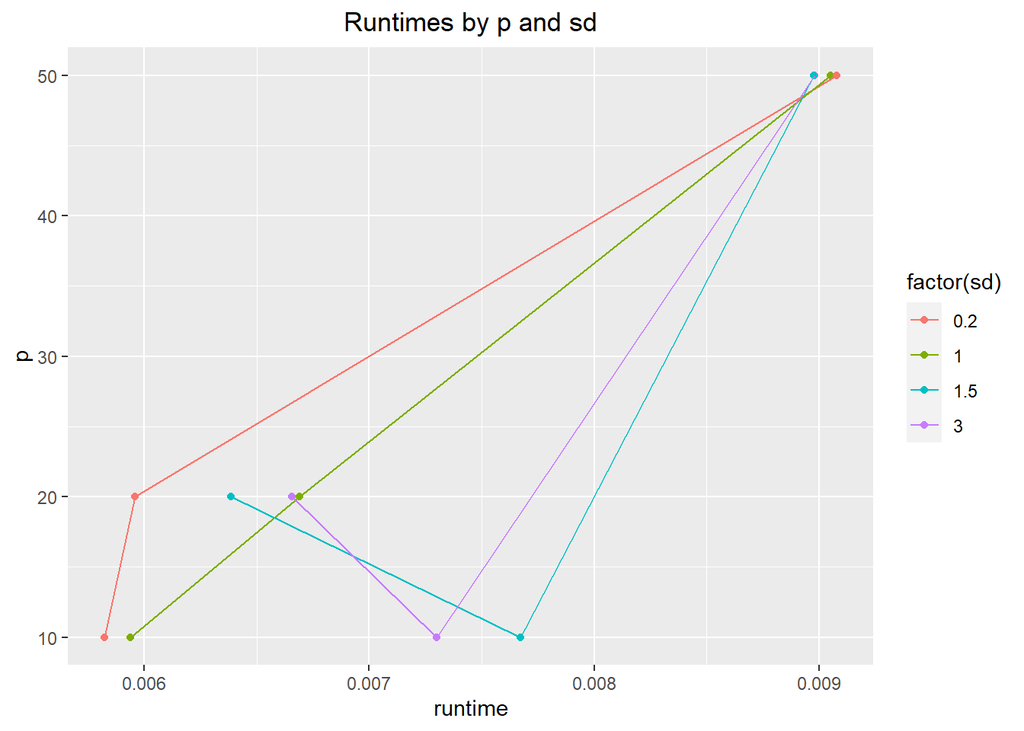

```r
#taking the runtimes data from the whole df
runtimes <- data.frame(df$p,df$sd,df$runtime)
colnames(runtimes) <- c("p","sd","runtime")

#ploting the runtimes by p and sd
ggplot(runtimes, aes(x=runtime,y=p, color=factor(sd)))+geom_point()+geom_line()+labs(title = "Runtimes by p and sd")+  theme(plot.title = element_text(hjust = 0.5))
```

By plotting the runtimes of all the p and sd we see ussually that the runtime depend on the p and not on the sd. ussually as much as the p is higher than the runtime is also longer, but beacuse of the randomal numbers and the simillarnece of the all 3 p’s we may get a different results which will not reflex this assumption. (the gaps between the runtime of all the p’s are really small..)

## 2 Comparing demographic and election data

### Using dendograms and similarity score for this comparison

```
## [1] "LC_COLLATE=Hebrew_Israel.1255;LC_CTYPE=Hebrew_Israel.1255;LC_MONETARY=Hebrew_Israel.1255;LC_NUMERIC=C;LC_TIME=Hebrew_Israel.1255"
```

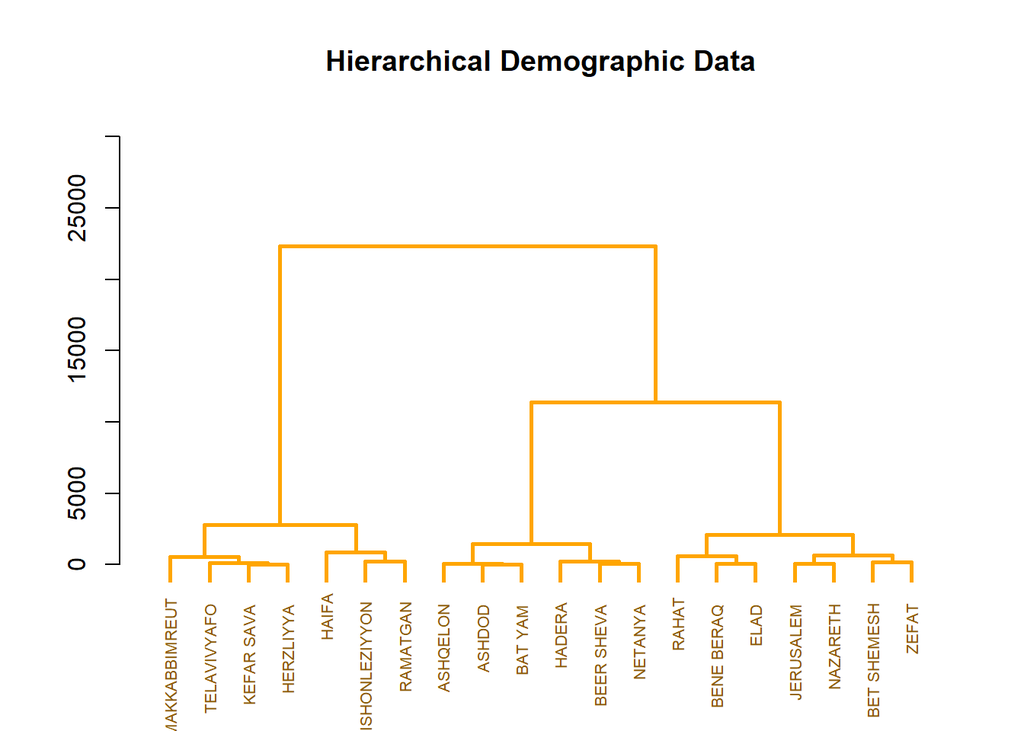

```r
#creating dendograms for the datasets
dend_cbs <- shared_cbs %>% dist(method = "euclidean") %>%  hclust(method = "ward.D" ) %>% as.dendrogram
dend_k <- shared_knesset %>% dist(method = "euclidean") %>%  hclust(method = "ward.D" ) %>% as.dendrogram

dend_cbs %>% hang.dendrogram %>% set("branches_lwd", 2.5) %>% set("branches_col", "orange") %>% set("labels_col", "orange4") %>%set("labels_cex", 0.65) %>% plot( cex = 0.6,main = "Hierarchical Demographic Data" ,ylim =c(0,30000), col.main= "black")
```

In the Demographic dedogram we chose to take only the variables that related to income: Income, pct_belowminimum and pct_wmn_noincome. We chose this varibles becouse they can create a clear picture about these cities and thier financical situation and avoid non relant data for this comparation.

We see in this dendogran that cities with a simmilar type of population are grouped together. We got a tree that reflects verry clearly the socio aconomical situation in Israel cities. (The aurtodox togheter, rich cities toghere and etc’.)

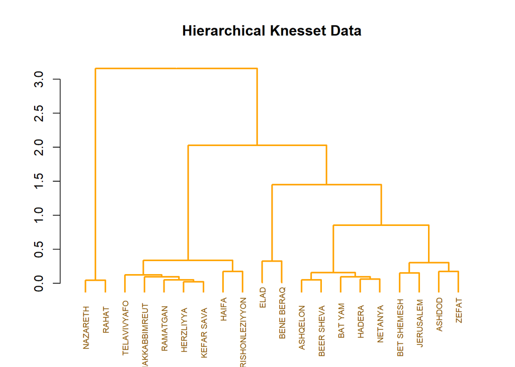

```r
dend_k %>% hang.dendrogram %>% set("branches_lwd", 2) %>%set("branches_col", "orange") %>% set("labels_col", "orange4") %>%set("labels_cex", 0.65) %>% plot( cex = 0.2, main ="Hierarchical Knesset Data", col.main= "black")
```

In this dendogram we see the voting in the chosen cites. In order to avoid the population size as variable we normalized the votes data. Here same as in the other dendogram we got a clear tree which represnts very well the cities group in their voting preferneces. We also see the arab cities are grouped toghere, as well as aourtodox and secular cites.

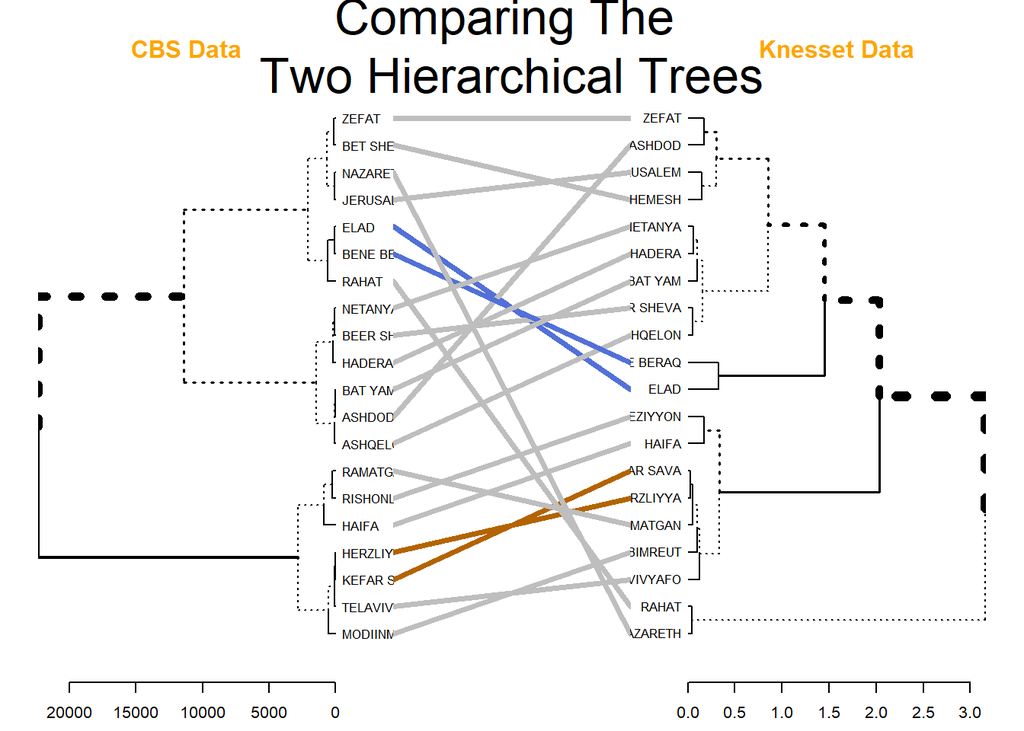

```r
dend_combine <- dendlist(dend_cbs, dend_k)
tanglegram( dend_combine, main_left = "CBS Data", main_right = "Knesset Data",col.main= "orange", main= "Comparing The \n Two Hierarchical Trees ",cex_main_left = 1.5, cex_main_right = 1.5, margin_top = 5,lab.cex =0.8, margin_outer = 2)
```

In this shared dendogram we see the comparison between the two trees we got before. We can see that a lot of cities got a close place in both sides of the tree,which reflects a similaration between the teo datasets, and two copules of cities (Beney Brak and Elad, Hertseliya and Kfar sava) got the excact group in both graphs what means a 100% match between those cities in this comparison.

```r
cor_cophenetic <-  cor_cophenetic(dend_cbs, dend_k)
print(paste("cor_cophenetic = ",round(cor_cophenetic,4)))
```

```
## [1] "cor_cophenetic =  0.5598"
```

Similarity Score: We chose the ‘Cophonetic distance’ method to compute the score. The value is the correlation similarity between two groups, and the range of it is between -1 and 1,with 0 meaning that the trees are not statisticall similar.

the Value we got is aprox 0.56 what shows that there is some statistical similar between the tree.

```r
p_val <- (sum(cor_cophenetic < score_vec))/ N
```

The hypothesis of this simulation: H0: there is no correlation between the knesset and cbs datasets. H1: there is a correlation between the datasets.

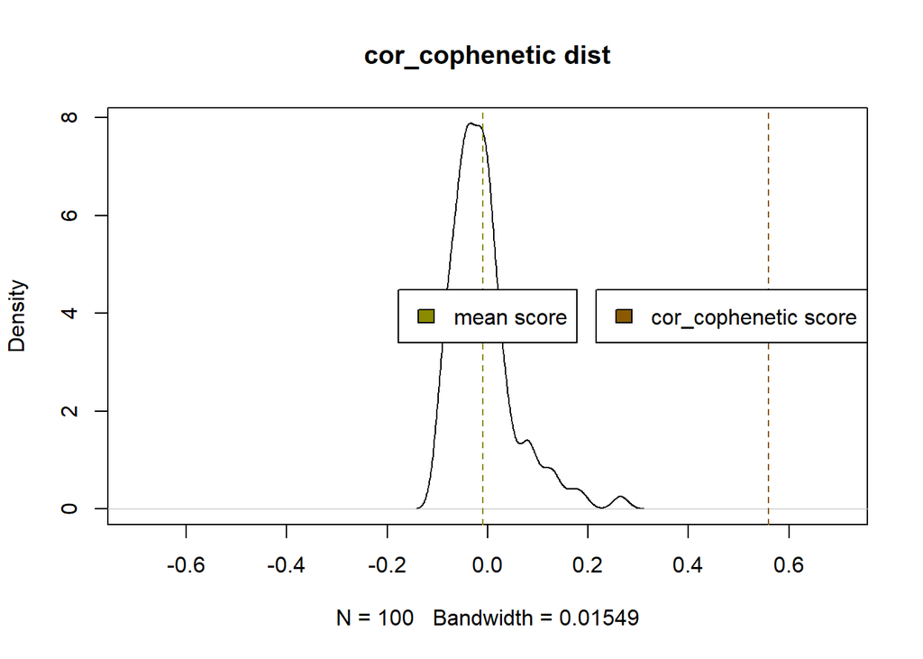

```r
plot(density(score_vec),
     main = "cor_cophenetic dist",
     xlim = c(-0.7,0.7))
     abline(v = cor_cophenetic, lty = 2, col = "orange4")
     abline(v=mean(score_vec), lty= 2, col ="yellow4")
    legend("right", legend =  "cor_cophenetic score", fill = "orange4")
    legend("center", legend =  "mean score", fill = "yellow4")
```